# O efeito no crescimento

```r
require(rstanarm)
require(dplyr)
```

Foram realizados três inventários florestais contínuos, com os quais foi possível determinar o incremento diamétrico anual. Anambé e Cauaxi representam inventário de um local cada. Já Tapajós, contemplou duas áreas florestais diferentes.

```r
anambe = read.csv('dados/anambe.csv')
tapajos = read.csv('dados/tapajos.csv')
cauaxi =  read.csv('dados/cauaxi.csv')

inv = rbind(anambe, tapajos, cauaxi)

inv = inv %>% filter(!is.na(ida))
```

## O efeito do local

Rapidamente é possível calcular o incremento diamétrico anual médio de cada local. A região de Anambé possui a maior taca de crescimento diamétrico, seguido por Tapajós 4, Cauaxi e por último, Tapajós 1.

```r
mediaInc = inv %>% group_by(base) %>% summarise(incMed = mean(ida))
mediaInc
```

| base | incMed |
| --- | --- |
| Anambe_PA | 0.5919857 |
| Cauaxi_PA | 0.4331733 |
| Tapajos_A01_2015_2016 | 0.3549749 |
| Tapajos_A04_2010_2011 | 0.5651742 |

A pergunta agora é saber se estes crescimento são diferentes entre si. Para isto, será utilizado um modelo Bayesiano.

```r
efeitoLocal = stan_glm(ida ~ base, family = gaussian(link = 'identity'), data = inv)
```

O modelo Bayesiano, assumindo distribuição normal para o incremento diamétrico anual, indica que Anambé, utilizado como intercepto, possui incremento médio (intercepto) igual a 0.5915293 cm/ano. Tapajós 4 possui coeficiente de -0.027272. Isto indica que este local, possui um incremento diamétrico, em média, igual ao intercepto. Já Cauaxi e Tapajós 1, possuem um incremento diamétrico anual médio 0.2 cm/ano inferior a Anambé. Lembrando que cada coeficiente possui uma estimativa da incerteza, indicada pelo valor médio de desvio (MAD). Neste caso, a incerteza em Tapajós 1 é maior que em Cauaxi.

```r
post
```

```
stan_glm
 family:       gaussian [identity]
 formula:      ida ~ base
 observations: 6032
 predictors:   4
------
                          Median MAD_SD
(Intercept)                0.6    0.0
baseCauaxi_PA             -0.2    0.0
baseTapajos_A01_2015_2016 -0.2    0.1
baseTapajos_A04_2010_2011  0.0    0.1

Auxiliary parameter(s):
      Median MAD_SD
sigma 1.3    0.0

------
* For help interpreting the printed output see ?print.stanreg
* For info on the priors used see ?prior_summary.stanreg
```

Graficamente, o resultado fica ainda mais interessante de se analisar. Veja que o intervalo do coeficiente de Tapajós 4 contém o valor zero. Desta forma, isto mostra que o valor de Tapajós 4 é o mesmo de Anambé (representado pelo intercepto). Já Cauaxi e tapajós 1 terial valores diferentes de Anambé, uma vez que seus coeficientes são diferentes de zero, e portanto mudariam o valor do intercepto (Anambé).

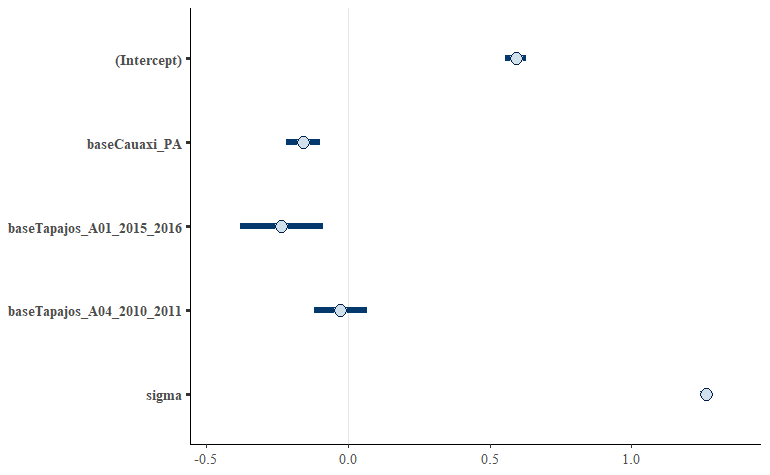

## O efeito do diâmetro

Imagine agora, se a pergunta for se o incremento diamétrico anual sofre influência do porte da árvore, expresso pelo seu diâmetro. Um modelo Bayesiano também pode ser usado, mas agora, tendo o diâmetro da árvore na primeira medição como variável independente.

```r
efeitoDap = stan_glm(ida ~ dap1, family = gaussian(link = 'identity'), data = anambe)
```

O grafico indica que existe sim a influência do diâmetro, uma vez que o coeficiente associado ao `dap1` é seguramente diferente de zero. Para cada unidade a mais no diâmetro, o incremento modifica em 0.0229882 cm/ano.

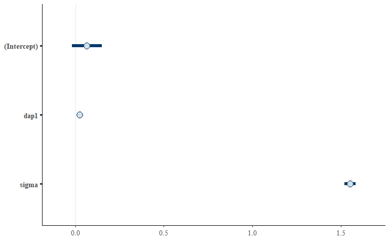

```r
plot(efeitoDap, prob = 0.9)
```